# regression models final project

Me

2025-11-23

## Executive Summary

Our model found that manual transmission cars have ~1.6 mpg more than automatic cars. However, the 95% CI for the effect of transmission type on MPG was approximately (-1.11, 4.30). Further, the p-value for the effect of transmission type was ~0.24. This result is not statistically significant, and we thus cannot infer that transmission type affects miles per gallon.

In practical terms, differences in mpg appear to be driven primarily by vehicle weight and engine performance characteristics, not transmission type.

## Project

The objective of this project is to answer the following questions: 1. Whether automatic or manual transmission is better for MPG, and 2. Quantify the MPG difference between automatic and manual.

```r
library(dplyr)
data(mtcars)
head(mtcars)
```

```
##                    mpg cyl disp  hp drat    wt  qsec vs am gear carb
## Mazda RX4         21.0   6  160 110 3.90 2.620 16.46  0  1    4    4
## Mazda RX4 Wag     21.0   6  160 110 3.90 2.875 17.02  0  1    4    4
## Datsun 710        22.8   4  108  93 3.85 2.320 18.61  1  1    4    1
## Hornet 4 Drive    21.4   6  258 110 3.08 3.215 19.44  1  0    3    1
## Hornet Sportabout 18.7   8  360 175 3.15 3.440 17.02  0  0    3    2
## Valiant           18.1   6  225 105 2.76 3.460 20.22  1  0    3    1
```

## EDA

So we can see that our columns of interest are “mpg” and “am”, which represent MPG and automatic/manual respectively. A 0 in “am” represents automatic transmission, while a 1 represents manual. Let us perform some EDA on the data.

```r
summary(mtcars)
```

```
##       mpg             cyl             disp             hp
##  Min.   :10.40   Min.   :4.000   Min.   : 71.1   Min.   : 52.0
##  1st Qu.:15.43   1st Qu.:4.000   1st Qu.:120.8   1st Qu.: 96.5
##  Median :19.20   Median :6.000   Median :196.3   Median :123.0
##  Mean   :20.09   Mean   :6.188   Mean   :230.7   Mean   :146.7
##  3rd Qu.:22.80   3rd Qu.:8.000   3rd Qu.:326.0   3rd Qu.:180.0
##  Max.   :33.90   Max.   :8.000   Max.   :472.0   Max.   :335.0
##       drat             wt             qsec             vs
##  Min.   :2.760   Min.   :1.513   Min.   :14.50   Min.   :0.0000
##  1st Qu.:3.080   1st Qu.:2.581   1st Qu.:16.89   1st Qu.:0.0000
##  Median :3.695   Median :3.325   Median :17.71   Median :0.0000
##  Mean   :3.597   Mean   :3.217   Mean   :17.85   Mean   :0.4375
##  3rd Qu.:3.920   3rd Qu.:3.610   3rd Qu.:18.90   3rd Qu.:1.0000
##  Max.   :4.930   Max.   :5.424   Max.   :22.90   Max.   :1.0000
##        am              gear            carb
##  Min.   :0.0000   Min.   :3.000   Min.   :1.000
##  1st Qu.:0.0000   1st Qu.:3.000   1st Qu.:2.000
##  Median :0.0000   Median :4.000   Median :2.000
##  Mean   :0.4062   Mean   :3.688   Mean   :2.812
##  3rd Qu.:1.0000   3rd Qu.:4.000   3rd Qu.:4.000
##  Max.   :1.0000   Max.   :5.000   Max.   :8.000
```

```r
table(mtcars$am)
```

```
##
##  0  1
## 19 13
```

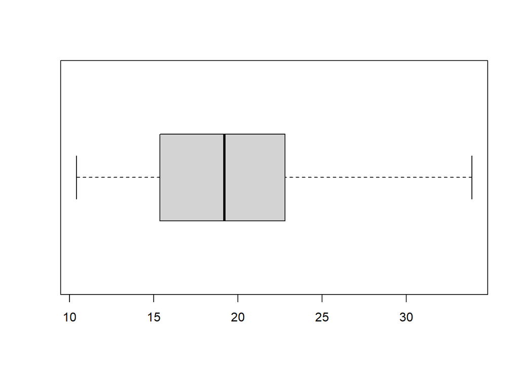

```r
boxplot(mtcars$mpg, horizontal=TRUE)
```

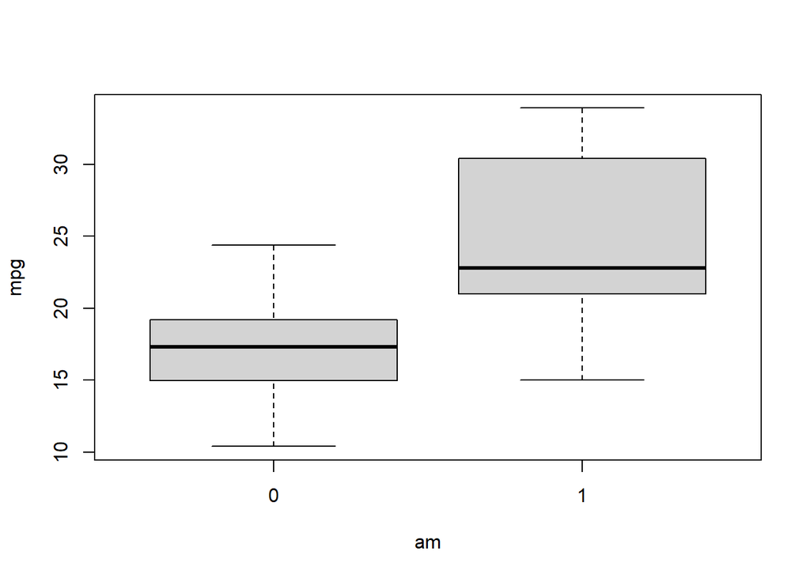

```r
boxplot(data = mtcars, mpg ~ am)
```

Okay so we can see the distribution of our mpg. We also see that we have 13 observations with manual transmission and 19 with automatic. Note: the sample size is quite small (32) so we should interpret results with caution. We can also see that the distribution of mpg looks smaller in value for automatic than for manual transmission.

## Model Selection

Now let us model a regression to answer our initial questions.

1. Is an automatic or manual transmission better for MPG?
2. Quantify the MPG difference between automatic and manual transmissions.

Since `am` is binary, let’s fit a generalized linear model (logistic regression) to it wrt `mpg`.

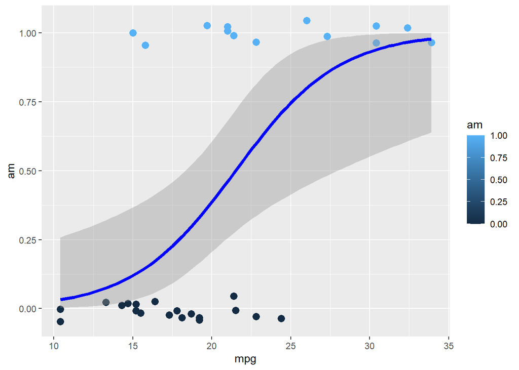

```r
mod1 <- glm(formula = am ~ mpg, family = binomial, data = mtcars)
library(ggplot2)
ggplot(data = mtcars, aes(x = mpg, y = am)) +
    geom_point(aes(color = am),
           size = 3,
           position = position_jitter(height = 0.05, width = 0)) +
    stat_smooth(method = "glm",
            method.args = list(family = "binomial"),
            se = TRUE,
            color = "blue", linewidth = 1.5)
```

```r
summary(mod1)
```

```
##
## Call:
## glm(formula = am ~ mpg, family = binomial, data = mtcars)
##
## Coefficients:
##             Estimate Std. Error z value Pr(>|z|)
## (Intercept)  -6.6035     2.3514  -2.808  0.00498 **
## mpg           0.3070     0.1148   2.673  0.00751 **
## ---
## Signif. codes:  0 '***' 0.001 '**' 0.01 '*' 0.05 '.' 0.1 ' ' 1
##
## (Dispersion parameter for binomial family taken to be 1)
##
##     Null deviance: 43.230  on 31  degrees of freedom
## Residual deviance: 29.675  on 30  degrees of freedom
## AIC: 33.675
##
## Number of Fisher Scoring iterations: 5
```

```r
confint(mod1)
```

```
##                   2.5 %     97.5 %
## (Intercept) -12.3281402 -2.7717638
## mpg           0.1220088  0.5874914
```

We can see that the 95% confidence interval for the logistic slope does not contain zero, so we can conclude that raising mpg does raises the chance of the car having manual transmission, to a statistically significant degree. However, this is P(am | mpg), while our questions ask for P(mpg | am). Let’s make some more models.

Let’s make a linear model, first checking to see which variables to include. We want variables that confound the relationship between `mpg` and `am`; uncorrelated regressors increase coefficient variance and decrease interpretability.

```r
library(MASS)
mod2 <- lm(formula = mpg ~ ., data = mtcars) %>% step(direction='backward', trace=0)
summary(mod2)
```

```
##
## Call:
## lm(formula = mpg ~ wt + qsec + am, data = mtcars)
##
## Residuals:
##     Min      1Q  Median      3Q     Max
## -3.4811 -1.5555 -0.7257  1.4110  4.6610
##
## Coefficients:
##             Estimate Std. Error t value Pr(>|t|)
## (Intercept)   9.6178     6.9596   1.382 0.177915
## wt           -3.9165     0.7112  -5.507 6.95e-06 ***
## qsec          1.2259     0.2887   4.247 0.000216 ***
## am            2.9358     1.4109   2.081 0.046716 *
## ---
## Signif. codes:  0 '***' 0.001 '**' 0.01 '*' 0.05 '.' 0.1 ' ' 1
##
## Residual standard error: 2.459 on 28 degrees of freedom
## Multiple R-squared:  0.8497, Adjusted R-squared:  0.8336
## F-statistic: 52.75 on 3 and 28 DF,  p-value: 1.21e-11
```

Okay so we used the Akaike Information Criterion to generate an initial model. AIC is a greedy algorithm, so we need to run some diagnostics on it to check if it is suitable. First, we can see that the model selected weight, 1/4 mile time, and automatic transmission as our regressors. The model explains ~83% of variance in our data and has an extremely low p-value. Let’s check for collinearity:

```r
library(car)
mod2 %>% vif
```

```
##       wt     qsec       am
## 2.482952 1.364339 2.541437
```

```r
mod2 %>% confint
```

```
##                   2.5 %    97.5 %
## (Intercept) -4.63829946 23.873860
## wt          -5.37333423 -2.459673
## qsec         0.63457320  1.817199
## am           0.04573031  5.825944
```

So far, so good. We have low VIFs meaning none of our variables are highly collinear (redundant). Our 95% CI for `am` does not include 0, so we are certain that am has a positive effect on mpg. Now, let’s drop `am` to see if that affects our model.

```r
mod3 <- lm(formula = mpg ~ wt + qsec, data=mtcars)
summary(mod3)
```

```
##
## Call:
## lm(formula = mpg ~ wt + qsec, data = mtcars)
##
## Residuals:
##     Min      1Q  Median      3Q     Max
## -4.3962 -2.1431 -0.2129  1.4915  5.7486
##
## Coefficients:
##             Estimate Std. Error t value Pr(>|t|)
## (Intercept)  19.7462     5.2521   3.760 0.000765 ***
## wt           -5.0480     0.4840 -10.430 2.52e-11 ***
## qsec          0.9292     0.2650   3.506 0.001500 **
## ---
## Signif. codes:  0 '***' 0.001 '**' 0.01 '*' 0.05 '.' 0.1 ' ' 1
##
## Residual standard error: 2.596 on 29 degrees of freedom
## Multiple R-squared:  0.8264, Adjusted R-squared:  0.8144
## F-statistic: 69.03 on 2 and 29 DF,  p-value: 9.395e-12
```

The values for this model are quite similar to the previous one. The p value went even lower for `wt`, increased slightly for `qsec`, and decreased slightly for the model overall. Our adjusted R^2 went down by ~2%.

```r
mod3 %>% vif
```

```
##       wt     qsec
## 1.031487 1.031487
```

Unsurprisingly, our two variables are practically completely uncorrelated.

```r
anova(mod2, mod3)
```

```
## Analysis of Variance Table
##
## Model 1: mpg ~ wt + qsec + am
## Model 2: mpg ~ wt + qsec
##   Res.Df    RSS Df Sum of Sq      F  Pr(>F)
## 1     28 169.29
## 2     29 195.46 -1   -26.178 4.3298 0.04672 *
## ---
## Signif. codes:  0 '***' 0.001 '**' 0.01 '*' 0.05 '.' 0.1 ' ' 1
```

```r
AIC(mod2, mod3)
```

```
##      df      AIC
## mod2  5 154.1194
## mod3  4 156.7205
```

Starting with AIC, we can see that including am slightly decreased the AIC, meaning the model has a marginally better fit. However, from anova we see that we have a statistically significant effect of adding `am` to our model. Therefore, we will proceed with the model which includes `am`, `wt`, and `qsec`.

## Model Analysis

```r
mod2 %>% summary
```

```
##
## Call:
## lm(formula = mpg ~ wt + qsec + am, data = mtcars)
##
## Residuals:
##     Min      1Q  Median      3Q     Max
## -3.4811 -1.5555 -0.7257  1.4110  4.6610
##
## Coefficients:
##             Estimate Std. Error t value Pr(>|t|)
## (Intercept)   9.6178     6.9596   1.382 0.177915
## wt           -3.9165     0.7112  -5.507 6.95e-06 ***
## qsec          1.2259     0.2887   4.247 0.000216 ***
## am            2.9358     1.4109   2.081 0.046716 *
## ---
## Signif. codes:  0 '***' 0.001 '**' 0.01 '*' 0.05 '.' 0.1 ' ' 1
##
## Residual standard error: 2.459 on 28 degrees of freedom
## Multiple R-squared:  0.8497, Adjusted R-squared:  0.8336
## F-statistic: 52.75 on 3 and 28 DF,  p-value: 1.21e-11
```

Accounting for weight and 1/4 mile time, the average MPG difference between manual and automatic cars is ~ 2.9 mpg. However, we should check model diagnostics to ensure that we can infer this result.

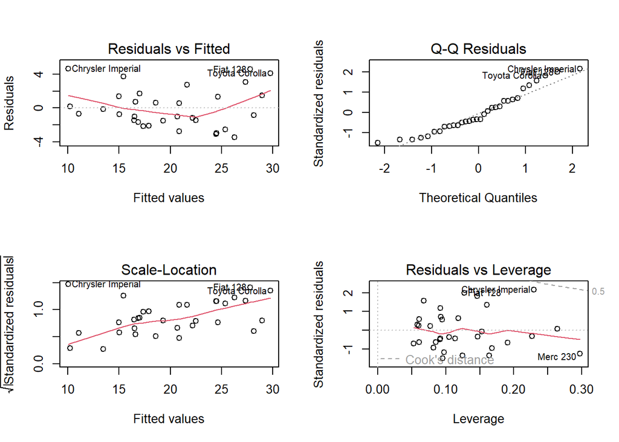

```r
par(mfrow=c(2,2))
plot(mod2)
```

Our residuals follow a slightly curved path, indicating minor non-linearity, which is probably not worrisome but worth noting. The Q-Q plot shows more-or-less normal data, with the exceptions being the right tail, indicating that the data is mildly right-skewed. The Scale-Location graph looks like it is slightly increasing, suggesting heteroscedasticity.

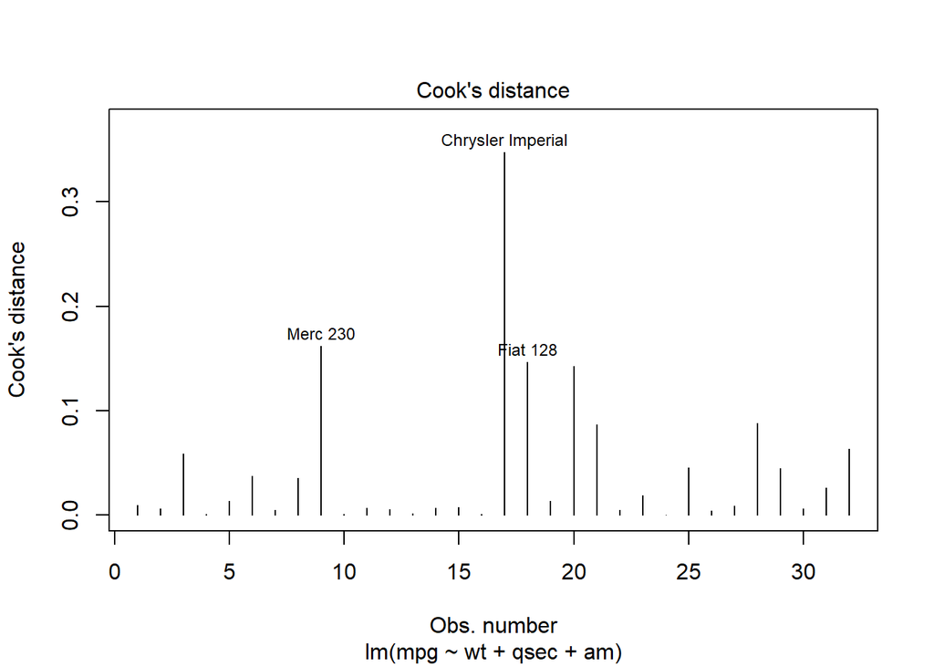

```r
par(mfrow=c(1,1))
plot(mod2, which=4)
```

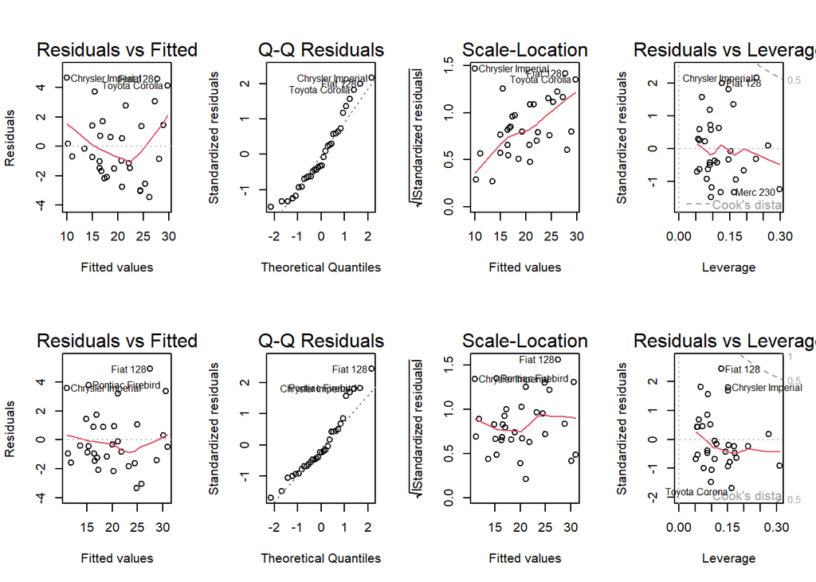

```r
mod4 <- lm(mpg ~ log(wt) + qsec + am, data=mtcars)
par(mfrow=c(2,4))
mod2 %>% plot
mod4 %>% plot
```

Let’s compare the two models.The residual plot for the newer model (model 4) is more linear than that of the older one (model 2), indicating higher linearity. The Q-Q plot of model 4 is slightly flatter, indicating residuals are closer to normal. The Scale-Location graph is much more even for model 4, suggesting homoscedasticity relative to model 2. Residual vs Leverage is similar for both.

```r
AIC(mod2, mod4)
```

```
##      df      AIC
## mod2  5 154.1194
## mod4  5 145.8160
```

```r
mod2 %>% vif
```

```
##       wt     qsec       am
## 2.482952 1.364339 2.541437
```

```r
mod4 %>% vif
```

```
##  log(wt)     qsec       am
## 2.837074 1.435307 2.897704
```

```r
mod4 %>% summary
```

```
##
## Call:
## lm(formula = mpg ~ log(wt) + qsec + am, data = mtcars)
##
## Residuals:
##     Min      1Q  Median      3Q     Max
## -3.3481 -1.4173 -0.4636  0.9587  4.9118
##
## Coefficients:
##             Estimate Std. Error t value Pr(>|t|)
## (Intercept)  16.4625     6.5533   2.512 0.018042 *
## log(wt)     -14.1980     2.0578  -6.900 1.69e-07 ***
## qsec          1.0592     0.2601   4.073 0.000345 ***
## am            1.5973     1.3232   1.207 0.237495
## ---
## Signif. codes:  0 '***' 0.001 '**' 0.01 '*' 0.05 '.' 0.1 ' ' 1
##
## Residual standard error: 2.16 on 28 degrees of freedom
## Multiple R-squared:  0.884,  Adjusted R-squared:  0.8716
## F-statistic: 71.14 on 3 and 28 DF,  p-value: 3.26e-13
```

```r
mod4 %>% confint
```

```
##                   2.5 %    97.5 %
## (Intercept)   3.0387448 29.886317
## log(wt)     -18.4131271 -9.982786
## qsec          0.5265111  1.591912
## am           -1.1132614  4.307817
```

Model 4 has a higher Adj-R^2 (it explains more variance). Model 4 beats model 2 on all above-mentioned criteria, so we will use it to test our hypotheses. Model 4 predicts that manual transmission cars have ~1.6 mpg more than automatic cars. However, our model did not find this to be statistically significant. Our 95% CI contains 0, so we cannot scientifically determine if automatic or manual transmission is better for mpg.

For curiosity’s sake, let’s remove `am` from our model to see if it even matters for predicting `mpg`.

```r
mod5 <- lm(mpg ~ log(wt) + qsec, mtcars)
mod5 %>% summary
```

```
##
## Call:
## lm(formula = mpg ~ log(wt) + qsec, data = mtcars)
##
## Residuals:
##     Min      1Q  Median      3Q     Max
## -4.0729 -1.3876 -0.4368  0.7493  5.4694
##
## Coefficients:
##             Estimate Std. Error t value Pr(>|t|)
## (Intercept)  22.2967     4.4603   4.999 2.54e-05 ***
## log(wt)     -16.1783     1.2519 -12.923 1.47e-13 ***
## qsec          0.8932     0.2224   4.016 0.000384 ***
## ---
## Signif. codes:  0 '***' 0.001 '**' 0.01 '*' 0.05 '.' 0.1 ' ' 1
##
## Residual standard error: 2.177 on 29 degrees of freedom
## Multiple R-squared:  0.878,  Adjusted R-squared:  0.8696
## F-statistic: 104.3 on 2 and 29 DF,  p-value: 5.661e-14
```

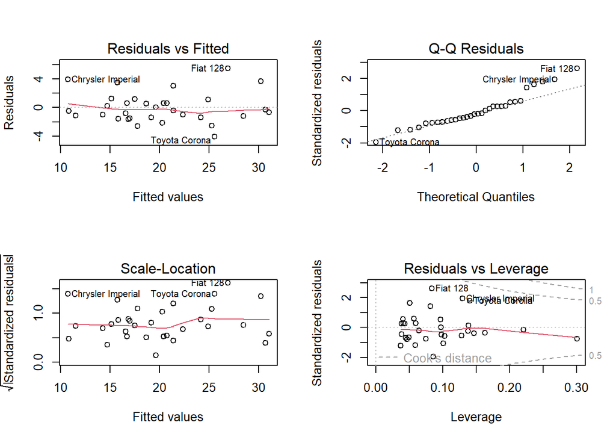

```r
par(mfrow=c(2,2))
mod5 %>% plot
```

```r
anova(mod4, mod5)
```

```
## Analysis of Variance Table
##
## Model 1: mpg ~ log(wt) + qsec + am
## Model 2: mpg ~ log(wt) + qsec
##   Res.Df    RSS Df Sum of Sq      F Pr(>F)
## 1     28 130.60
## 2     29 137.39 -1    -6.796 1.4571 0.2375
```

We can see that in our new model (which has very reasonable diagnostic plots), the variance explained is practically the same, with our predictors being highly statistically significant. Our ANOVA predicts that adding `am` to the model does not increase predictive power to a statistically significant degree. Thus, we can conclude that after adjusting for confounders, `am` does NOT have an independent influence on `mpg`, backing up our model 4 summary.